# Bank Customer Churn Prediction

### **ESPECIALIZACIÓN EN CIENCIA DE DATOS E INGELIGENCIA ARTIFICIAL**

### **Fundamentos de programación**

### **Tema:** Proyecto final - Bank Customer Churn Prediction

###### **Estudiantes:** Juan Pablo Madrigal Navarro & Johana Marcela Hidalgo Zuluaga **FECHA:** 2026-08-15

## Objetivo del proyecto

Este proyecto analiza un conjunto de datos que contiene información sobre los clientes de un banco, con el propósito de identificar las principales características y factores asociados a la deserción de clientes (churn). A partir del análisis de las diferentes variables disponibles, se busca comprender qué características presentan los clientes que abandonan el banco y cuáles se relacionan con su permanencia. Para orientar el análisis, se plantearon las siguientes preguntas:

- ¿Cuál es el porcentaje de clientes que abandonó el banco y cuál permaneció?
- ¿La edad influye en la decisión de abandonar el banco?
- ¿Existe diferencia en la deserción entre hombres y mujeres?
- ¿Qué país presenta la mayor tasa de abandono de clientes?
- ¿Los clientes con mayor saldo tienen más probabilidad de abandonar el banco?
- ¿Ser un cliente activo reduce la probabilidad de abandonar el banco?
- ¿Los clientes con tarjeta de crédito abandonan menos que los que no la tienen?
- ¿Existe relación entre el puntaje de crédito y la deserción de clientes ?
- ¿El número de productos contratados influye en la permanencia del cliente?
- ¿Qué porcentaje abandona dentro de cada combinación de productos y actividad?
- ¿Qué porcentaje de clientes abandona el banco según el número de productos contratados y su condición de cliente activo o inactivo?
- ¿Qué características tienen, en promedio, los clientes que abandonan el banco frente a los que permanecen?

## 1. Carga de los datos y librerías utilizadas

Para iniciar el proyecto, se realizó la carga del conjunto de datos **Bank Customer Churn Prediction**, obtenido desde Kaggle mediante la biblioteca **KaggleHub**. Esta herramienta permitió acceder y cargar directamente el archivo `Churn_Modelling.csv` en el entorno de Python, facilitando el trabajo con la información de los clientes y las variables relacionadas con la deserción.

Durante el desarrollo del proyecto se utilizaron diferentes librerías de Python para realizar el análisis y la visualización de los datos. **Pandas** se empleó principalmente para la manipulación, organización y análisis de los datos mediante DataFrames, así como para la construcción de tablas de frecuencias y agrupaciones. **NumPy** se utilizó para realizar cálculos numéricos y estadísticos, como el cálculo de percentiles y la identificación de valores atípicos mediante el rango intercuartílico (IQR).

**Matplotlib** permitió generar diferentes visualizaciones, como histogramas, gráficos de barras y diagramas de dona, mientras que **Seaborn** se utilizó para complementar la representación gráfica de los datos mediante gráficos estadísticos. Finalmente, **KaggleHub** facilitó la obtención del conjunto de datos directamente desde Kaggle, haciendo más sencillo el proceso de carga de la información al entorno de trabajo.

```python
!pip3 install kagglehub
```

```python
!pip3 install pandas
```

```python
!pip3 install numpy
```

```python
pip install matplotlib seaborn
```

## 2. Cargar el dataset

Una vez instalada la biblioteca KaggleHub, copiamos el código proporcionado en la página de Kaggle para cargar el conjunto de datos en nuestro entorno de trabajo. Esto nos permitió acceder a la información y dar inicio al proceso de inspección y exploración de los datos.

```python
import kagglehub
from kagglehub import KaggleDatasetAdapter

# Set the path to the file you'd like to load
file_path = "Churn_Modelling.csv"

# Load the latest version
df = kagglehub.load_dataset(
  KaggleDatasetAdapter.PANDAS,
  "shantanudhakadd/bank-customer-churn-prediction",
  file_path,
  # Provide any additional arguments like
  # sql_query or pandas_kwargs. See the
  # documenation for more information:
  # https://github.com/Kaggle/kagglehub/blob/main/README.md#kaggledatasetadapterpandas
)

print("First 5 records:", df.head())
```

[output not shown]

## 3. Inspección y exploración de los datos

A continuación, identificamos la cantidad de filas y columnas que componen el conjunto de datos. En este caso, observamos que el *dataset* está conformado por **10.000 filas** y **14 columnas**

```python
df.shape
```

```
(10000, 14)
```

Posteriormente, identificamos los tipos de datos presentes en las columnas del conjunto de datos. Como resultado del análisis, observamos que existen **tres tipos de datos**: **enteros (`int`)**, utilizados para valores numéricos sin decimales; **decimales (`float`)**, empleados para valores numéricos con parte decimal; y **objetos (`object`)**, correspondientes a datos de tipo texto o cadenas de caracteres.

```python
df.dtypes
```

```
RowNumber            int64
CustomerId           int64
Surname             object
CreditScore          int64
Geography           object
Gender              object
Age                  int64
Tenure               int64
Balance            float64
NumOfProducts        int64
HasCrCard            int64
IsActiveMember       int64
EstimatedSalary    float64
Exited               int64
dtype: object
```

A continuación, visualizamos las primeras filas del conjunto de datos con el fin de conocer su estructura y la forma en que está organizada la información. Esta inspección inicial nos permite identificar las variables disponibles, verificar que los datos se hayan cargado correctamente y obtener una comprensión general del contenido del *dataset* antes de iniciar su análisis.

```python
df.head()
```

|  | RowNumber | CustomerId | Surname | CreditScore | Geography | Gender | Age | Tenure | Balance | NumOfProducts | HasCrCard | IsActiveMember | EstimatedSalary | Exited |
| --- | --- | --- | --- | --- | --- | --- | --- | --- | --- | --- | --- | --- | --- | --- |
| 0 | 1 | 15634602 | Hargrave | 619 | France | Female | 42 | 2 | 0.00 | 1 | 1 | 1 | 101348.88 | 1 |
| 1 | 2 | 15647311 | Hill | 608 | Spain | Female | 41 | 1 | 83807.86 | 1 | 0 | 1 | 112542.58 | 0 |
| 2 | 3 | 15619304 | Onio | 502 | France | Female | 42 | 8 | 159660.80 | 3 | 1 | 0 | 113931.57 | 1 |
| 3 | 4 | 15701354 | Boni | 699 | France | Female | 39 | 1 | 0.00 | 2 | 0 | 0 | 93826.63 | 0 |
| 4 | 5 | 15737888 | Mitchell | 850 | Spain | Female | 43 | 2 | 125510.82 | 1 | 1 | 1 | 79084.10 | 0 |

En esta etapa se verificó la existencia de valores nulos en cada una de las columnas del conjunto de datos. Como resultado del análisis, se evidenció que **ninguna de las variables presenta valores nulos**, lo que indica que el *dataset* está completo y no requiere procesos de limpieza relacionados con datos faltantes antes de continuar con el análisis y la construcción de modelos predictivos.

```python
df.info()
```

```
<class 'pandas.core.frame.DataFrame'>
RangeIndex: 10000 entries, 0 to 9999
Data columns (total 14 columns):
 #   Column           Non-Null Count  Dtype
---  ------           --------------  -----
 0   RowNumber        10000 non-null  int64
 1   CustomerId       10000 non-null  int64
 2   Surname          10000 non-null  object
 3   CreditScore      10000 non-null  int64
 4   Geography        10000 non-null  object
 5   Gender           10000 non-null  object
 6   Age              10000 non-null  int64
 7   Tenure           10000 non-null  int64
 8   Balance          10000 non-null  float64
 9   NumOfProducts    10000 non-null  int64
 10  HasCrCard        10000 non-null  int64
 11  IsActiveMember   10000 non-null  int64
 12  EstimatedSalary  10000 non-null  float64
 13  Exited           10000 non-null  int64
dtypes: float64(2), int64(9), object(3)
memory usage: 1.1+ MB
```

```python
df.isnull().sum()
```

```
RowNumber          0
CustomerId         0
Surname            0
CreditScore        0
Geography          0
Gender             0
Age                0
Tenure             0
Balance            0
NumOfProducts      0
HasCrCard          0
IsActiveMember     0
EstimatedSalary    0
Exited             0
dtype: int64
```

En esta etapa se verificó la existencia de registros duplicados en el conjunto de datos, tomando como referencia la columna **CustomerId**, ya que esta corresponde al identificador único de cada cliente. El objetivo de esta validación es garantizar la integridad de la información y asegurar que cada cliente se encuentre representado una única vez dentro del *dataset*, evitando posibles sesgos o inconsistencias en el análisis posterior.

```python
df["CustomerId"].duplicated().sum()
```

```
np.int64(0)
```

En esta etapa se identificó que todas las columnas contienen la totalidad de los registros, dado que el valor de count es igual al número de filas del dataset para cada variable. Esto indica, inicialmente, que no se presentan valores faltantes en las columnas analizadas. En cuanto a CreditScore, se observa un valor mínimo de 350 y un valor máximo de 850, encontrándose ambos dentro del rango establecido de 0 a 1000. Adicionalmente, la variable presenta un promedio de 650 puntos y una desviación estándar de 97 puntos, lo que evidencia una variabilidad moderada en los puntajes de crédito.

Por otra parte, la edad de los clientes se encuentra entre los 18 y 92 años, con una edad promedio de 39 años. Este análisis también permite realizar una primera validación de la calidad de los datos, ya que no se identifican edades fuera de rangos razonables o valores que puedan considerarse inconsistentes.

```python
df.describe()
```

|  | RowNumber | CustomerId | CreditScore | Age | Tenure | Balance | NumOfProducts | HasCrCard | IsActiveMember | EstimatedSalary | Exited |
| --- | --- | --- | --- | --- | --- | --- | --- | --- | --- | --- | --- |
| count | 10000.00000 | 1.000000e+04 | 10000.000000 | 10000.000000 | 10000.000000 | 10000.000000 | 10000.000000 | 10000.00000 | 10000.000000 | 10000.000000 | 10000.000000 |
| mean | 5000.50000 | 1.569094e+07 | 650.528800 | 38.921800 | 5.012800 | 76485.889288 | 1.530200 | 0.70550 | 0.515100 | 100090.239881 | 0.203700 |
| std | 2886.89568 | 7.193619e+04 | 96.653299 | 10.487806 | 2.892174 | 62397.405202 | 0.581654 | 0.45584 | 0.499797 | 57510.492818 | 0.402769 |
| min | 1.00000 | 1.556570e+07 | 350.000000 | 18.000000 | 0.000000 | 0.000000 | 1.000000 | 0.00000 | 0.000000 | 11.580000 | 0.000000 |
| 25% | 2500.75000 | 1.562853e+07 | 584.000000 | 32.000000 | 3.000000 | 0.000000 | 1.000000 | 0.00000 | 0.000000 | 51002.110000 | 0.000000 |
| 50% | 5000.50000 | 1.569074e+07 | 652.000000 | 37.000000 | 5.000000 | 97198.540000 | 1.000000 | 1.00000 | 1.000000 | 100193.915000 | 0.000000 |
| 75% | 7500.25000 | 1.575323e+07 | 718.000000 | 44.000000 | 7.000000 | 127644.240000 | 2.000000 | 1.00000 | 1.000000 | 149388.247500 | 0.000000 |
| max | 10000.00000 | 1.581569e+07 | 850.000000 | 92.000000 | 10.000000 | 250898.090000 | 4.000000 | 1.00000 | 1.000000 | 199992.480000 | 1.000000 |

Se observa que Francia es el país con mayor representación en el conjunto de datos, con un 50,14 % del total de registros. Por su parte, Alemania y España representan el 25,09 % y 24,77 %, respectivamente. Esto evidencia una distribución relativamente equilibrada entre Alemania y España, mientras que Francia concentra aproximadamente la mitad de los registros.

En cuanto a la distribución por género, se observa una mayor proporción de hombres (54,57 %) frente a las mujeres (45,43 %). Aunque existe una diferencia de 9,14 puntos porcentuales, la distribución se mantiene relativamente equilibrada entre ambos grupos.

De acuerdo con los conocimientos adquiridos en clase, se realiza un análisis de la distribución porcentual de los clientes según su género y ubicación geográfica, utilizando un diccionario como parte de la aplicación práctica de los conceptos aprendidos durante el curso.

```python
import pandas as pd

cantidad = df["Gender"].value_counts()
total = len(df)
porcentaje = ((cantidad / total) * 100).round(2)
tabla = pd.DataFrame({"cantidad": cantidad,"porcentaje": porcentaje})

print(tabla)
```

```
        cantidad  porcentaje
Gender
Male        5457       54.57
Female      4543       45.43
```

```python
#Con diccionario
import pandas as pd

cantidad = df["Gender"].value_counts()
total = len(df)
datos = {}

for genero in cantidad.index:
    datos[genero] = {"cantidad": cantidad[genero],"porcentaje": round((cantidad[genero] / total) * 100, 2)}

tabla = pd.DataFrame(datos).T

print(tabla)
```

```
        cantidad  porcentaje
Male      5457.0       54.57
Female    4543.0       45.43
```

```python
cantidad = df["Geography"].value_counts()

total = len(df)
porcentaje = ((cantidad / total) * 100).round(2)
tabla = pd.DataFrame({"cantidad": cantidad,"porcentaje": porcentaje})

print(tabla)
```

```
           cantidad  porcentaje
Geography
France         5014       50.14
Germany        2509       25.09
Spain          2477       24.77
```

```python
#Con diccionario
import pandas as pd

cantidad = df["Geography"].value_counts()
total = len(df)
datos = {}

for pais in cantidad.index:
    datos[pais] = {"cantidad": cantidad[pais],"porcentaje": round((cantidad[pais] / total) * 100, 2)}

tabla = pd.DataFrame(datos).T

print(tabla)
```

```
         cantidad  porcentaje
France     5014.0       50.14
Germany    2509.0       25.09
Spain      2477.0       24.77
```

Las variables de tipo string y binarias se encuentran dentro de los parámetros establecidos y no presentan valores inconsistentes. A partir de los análisis realizados anteriormente, se concluye que el dataset presenta una estructura adecuada y no requiere una normalización de los datos en esta etapa del análisis.

```python
print(df['Geography'].unique())
print(df['Gender'].unique())
print(df['HasCrCard'].unique())
print(df['IsActiveMember'].unique())
print(df['Exited'].unique())
```

```
['France' 'Spain' 'Germany']
['Female' 'Male']
[1 0]
[1 0]
[1 0]
```

Aplicando los conocimientos adquiridos en clase, se realiza un análisis de los valores atípicos (outliers) utilizando NumPy y el método del rango intercuartílico (IQR). Se eligió este método porque permite identificar de forma sencilla los valores que se encuentran alejados del comportamiento general de los datos y es adecuado para analizar las variables numéricas del conjunto de datos.

Aunque se identificaron valores atípicos (outliers) en algunas variables numéricas, como CreditScore, Age y NumOfProducts, se decidió conservarlos, ya que representan observaciones válidas y relevantes para el análisis que se desea realizar. Por lo tanto, no se eliminarán ni modificarán estos registros, con el fin de preservar la información original del dataset y evitar la pérdida de datos potencialmente significativos.

```python
columnas = ['CreditScore', 'Age', 'Tenure', 'Balance','NumOfProducts', 'EstimatedSalary']

for columna in columnas:
    Q1 = df[columna].quantile(0.25)
    Q3 = df[columna].quantile(0.75)

    IQR = Q3 - Q1

    limite_inferior = Q1 - 1.5 * IQR
    limite_superior = Q3 + 1.5 * IQR

    outliers = df[
        (df[columna] < limite_inferior) |
        (df[columna] > limite_superior)
    ]

    print(columna)
    print('Límite inferior:', limite_inferior)
    print('Límite superior:', limite_superior)
    print('Cantidad de outliers:', len(outliers))
    print()
```

```
CreditScore
Límite inferior: 383.0
Límite superior: 919.0
Cantidad de outliers: 15

Age
Límite inferior: 14.0
Límite superior: 62.0
Cantidad de outliers: 359

Tenure
Límite inferior: -3.0
Límite superior: 13.0
Cantidad de outliers: 0

Balance
Límite inferior: -191466.36000000002
Límite superior: 319110.60000000003
Cantidad de outliers: 0

NumOfProducts
Límite inferior: -0.5
Límite superior: 3.5
Cantidad de outliers: 60

EstimatedSalary
Límite inferior: -96577.09624999999
Límite superior: 296967.45375
Cantidad de outliers: 0
```

```python
# Analisis de outliers con numpy
import numpy as np

columnas = ['CreditScore', 'Age', 'Tenure', 'Balance','NumOfProducts', 'EstimatedSalary']

for columna in columnas:
    Q1 = np.percentile(df[columna], 25)
    Q3 = np.percentile(df[columna], 75)

    IQR = Q3 - Q1

    limite_inferior = Q1 - 1.5 * IQR
    limite_superior = Q3 + 1.5 * IQR

    outliers = df[(df[columna] < limite_inferior) | (df[columna] > limite_superior)]

    print(columna)
    print("Límite inferior:", round(limite_inferior, 2))
    print("Límite superior:", round(limite_superior, 2))
    print("Cantidad de outliers:", len(outliers))
    print()
```

```
CreditScore
Límite inferior: 383.0
Límite superior: 919.0
Cantidad de outliers: 15

Age
Límite inferior: 14.0
Límite superior: 62.0
Cantidad de outliers: 359

Tenure
Límite inferior: -3.0
Límite superior: 13.0
Cantidad de outliers: 0

Balance
Límite inferior: -191466.36
Límite superior: 319110.6
Cantidad de outliers: 0

NumOfProducts
Límite inferior: -0.5
Límite superior: 3.5
Cantidad de outliers: 60

EstimatedSalary
Límite inferior: -96577.1
Límite superior: 296967.45
Cantidad de outliers: 0
```

## 4. Respuestas a las preguntas objetivo

## ¿Cuál es el porcentaje de clientes que abandonó el banco y cuál permaneció?

Como se puede observar en la gráfica, los clientes retenidos representan el 79,63 % del total, correspondiente a 7.963 clientes. Por otro lado, los clientes que desertaron representan el 20,37 %, equivalentes a 2.037 clientes. Esto evidencia que, aunque la mayoría de los clientes permanecen en la compañía, aproximadamente 1 de cada 5 clientes ha desertado, lo que representa un porcentaje relevante para el análisis de deserción.

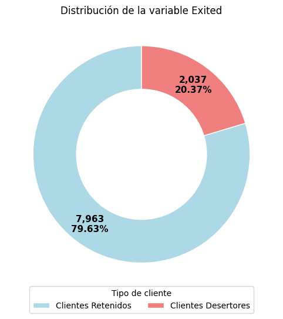

```python
import numpy as np
import matplotlib.pyplot as plt

cantidad = df["Exited"].value_counts().sort_index()
total = len(df)
porcentaje = (cantidad / total) * 100
etiquetas = ["Clientes Retenidos", "Clientes Desertores"]

fig, ax = plt.subplots(figsize=(8, 6))

colores = ["lightblue", "lightcoral"]

wedges, texts = ax.pie(
    cantidad,
    startangle=90,
    colors=colores,
    wedgeprops=dict(width=0.4, edgecolor="white")
)

for i, wedge in enumerate(wedges):
    angulo = (wedge.theta2 + wedge.theta1) / 2
    x = 0.8 * np.cos(np.radians(angulo))
    y = 0.8 * np.sin(np.radians(angulo))

    ax.text(
        x, y,
        f"{cantidad.iloc[i]:,}\n{porcentaje.iloc[i]:.2f}%",
        ha="center",
        va="center",
        fontsize=11,
        fontweight="bold",
        color="black"
    )

# Leyenda
ax.legend(
    wedges,
    etiquetas,
    title="Tipo de cliente",
    loc="lower center",
    bbox_to_anchor=(0.5, -0.10),
    ncol=2
)

ax.set_title("Distribución de la variable Exited")

plt.show()
```

## ¿La edad influye en la decisión de abandonar el banco?

Para este análisis se realizó una agrupación de los clientes por rango de edad y condición de permanencia en el banco (retenido o desertor). Los resultados evidencian diferencias en la distribución de la deserción entre los distintos grupos de edad. En particular, los segmentos correspondientes a adulto mayor y anciano concentran conjuntamente el 77,32 % de los clientes que abandonaron el banco. Esto permite identificar una posible asociación entre la edad y la deserción, aunque no implica que la edad sea una causa directa del abandono. A partir de estos resultados, se recomienda desarrollar estrategias de retención orientadas a estos segmentos, enfocadas en comprender sus necesidades y fortalecer su relación con el banco.

```python
def clasificar_edad(edad):
    if edad >= 18 and edad < 28:
        return "Joven Adulto"
    elif edad >= 28 and edad < 38:
        return "Adulto"
    elif edad >= 38 and edad < 48:
        return "Adulto Mayor"
    else:
        return "Anciano"

nuevo_df = df.copy()
nuevo_df["Rango de edades"] = df["Age"].apply(clasificar_edad)
```

```python
def clasificar_Exited(Exited):
    if Exited ==1:
        return "Clientes Desertores"
    else:
        return "Clientes Retenidos"
Exited_df = nuevo_df.copy()
Exited_df["Tipo_Clientes"] = df["Exited"].apply(clasificar_Exited)
```

```python
Exited_df.head()
```

|  | RowNumber | CustomerId | Surname | CreditScore | Geography | Gender | Age | Tenure | Balance | NumOfProducts | HasCrCard | IsActiveMember | EstimatedSalary | Exited | Rango de edades | Tipo_Clientes |
| --- | --- | --- | --- | --- | --- | --- | --- | --- | --- | --- | --- | --- | --- | --- | --- | --- |
| 0 | 1 | 15634602 | Hargrave | 619 | France | Female | 42 | 2 | 0.00 | 1 | 1 | 1 | 101348.88 | 1 | Adulto Mayor | Clientes Desertores |
| 1 | 2 | 15647311 | Hill | 608 | Spain | Female | 41 | 1 | 83807.86 | 1 | 0 | 1 | 112542.58 | 0 | Adulto Mayor | Clientes Retenidos |
| 2 | 3 | 15619304 | Onio | 502 | France | Female | 42 | 8 | 159660.80 | 3 | 1 | 0 | 113931.57 | 1 | Adulto Mayor | Clientes Desertores |
| 3 | 4 | 15701354 | Boni | 699 | France | Female | 39 | 1 | 0.00 | 2 | 0 | 0 | 93826.63 | 0 | Adulto Mayor | Clientes Retenidos |
| 4 | 5 | 15737888 | Mitchell | 850 | Spain | Female | 43 | 2 | 125510.82 | 1 | 1 | 1 | 79084.10 | 0 | Adulto Mayor | Clientes Retenidos |

```python
desertores = Exited_df[Exited_df["Tipo_Clientes"] == "Clientes Desertores"]["Rango de edades"].value_counts()
resultado = pd.DataFrame({"Cantidad": desertores,"Porcentaje": (desertores / desertores.sum() * 100).round(2)})
resultado
```

| Rango de edades | Cantidad | Porcentaje |
| --- | --- | --- |
| Anciano | 789 | 38.73 |
| Adulto Mayor | 786 | 38.59 |
| Adulto | 389 | 19.10 |
| Joven Adulto | 73 | 3.58 |

## ¿Existe diferencia en la deserción entre hombres y mujeres?

Se observa una diferencia en la tasa de deserción según el género. Las mujeres presentan una tasa de abandono del 25,07 %, frente al 16,46 % de los hombres, lo que representa una diferencia de 8,61 puntos porcentuales. Por lo tanto, las mujeres presentan una mayor tasa de deserción en el conjunto de datos analizado, aunque esto representa una asociación y no implica que el género sea una causa directa del abandono.

```python
resultado = pd.crosstab(Exited_df["Gender"],Exited_df["Tipo_Clientes"])
resultado["Tasa_Desercion_%"] = (
    resultado["Clientes Desertores"] /resultado[["Clientes Retenidos", "Clientes Desertores"]].sum(axis=1)* 100).round(2)
resultado
```

| Tipo_Clientes Gender | Clientes Desertores | Clientes Retenidos | Tasa_Desercion_% |
| --- | --- | --- | --- |
| Female | 1139 | 3404 | 25.07 |
| Male | 898 | 4559 | 16.46 |

## ¿Qué país presenta la mayor tasa de abandono de clientes?

```python
desertores = Exited_df[Exited_df["Tipo_Clientes"] == "Clientes Desertores"]["Geography"].value_counts()

resultado = pd.DataFrame({"Cantidad": desertores,"Porcentaje": (desertores / desertores.sum() * 100).round(2)})

resultado
```

| Geography | Cantidad | Porcentaje |
| --- | --- | --- |
| Germany | 814 | 39.96 |
| France | 810 | 39.76 |
| Spain | 413 | 20.27 |

## ¿Los clientes con mayor saldo tienen más probabilidad de abandonar el banco?

Los resultados muestran una diferencia en la tasa de deserción según el nivel de saldo. Los clientes con saldo alto presentan una tasa de abandono del 24,09 %, mientras que los clientes con saldo bajo presentan una tasa del 14,97 %. Esto representa una diferencia de 9,12 puntos porcentuales, lo que indica que, dentro del conjunto de datos analizado, los clientes con saldos superiores a la media presentan una mayor tasa de deserción. Sin embargo, este resultado representa una asociación entre el nivel de saldo y la deserción, por lo que no permite afirmar que tener un saldo alto sea una causa directa del abandono. A partir de estos resultados, se recomienda prestar especial atención a los clientes con saldos altos mediante estrategias de seguimiento y fidelización, con el propósito de identificar posibles factores de insatisfacción y prevenir su abandono.

```python
Balance_df = Exited_df.copy()

media_balance = Balance_df["Balance"].mean()

Balance_df["Nivel_Saldo"] = np.where(Balance_df["Balance"] > media_balance,"Saldo alto","Saldo bajo")

resultado = pd.crosstab(Balance_df["Nivel_Saldo"],Balance_df["Tipo_Clientes"])

resultado["Tasa_Desercion_%"] = (resultado["Clientes Desertores"] /resultado[["Clientes Desertores", "Clientes Retenidos"]].sum(axis=1)* 100).round(2)

resultado
```

| Tipo_Clientes Nivel_Saldo | Clientes Desertores | Clientes Retenidos | Tasa_Desercion_% |
| --- | --- | --- | --- |
| Saldo alto | 1426 | 4493 | 24.09 |
| Saldo bajo | 611 | 3470 | 14.97 |

## ¿Ser un cliente activo reduce la probabilidad de abandonar el banco?

Los clientes activos presentan una tasa de deserción del 14,27 %, mientras que los clientes inactivos alcanzan el 26,85 %. La diferencia de 12,58 puntos porcentuales indica que los clientes activos presentan una menor tasa de abandono, por lo que la actividad del cliente se relaciona con una mayor permanencia en el banco.

```python
resultado_actividad = pd.crosstab(Balance_df ["IsActiveMember"],Balance_df ["Tipo_Clientes"])

resultado_actividad["Tasa_Desercion_%"] = (resultado_actividad["Clientes Desertores"] /resultado_actividad[["Clientes Desertores", "Clientes Retenidos"]].sum(axis=1)* 100).round(2)

resultado_actividad.index = resultado_actividad.index.map({0: "Clientes Inactivos",1: "Clientes Activos"})

resultado_actividad
```

| Tipo_Clientes IsActiveMember | Clientes Desertores | Clientes Retenidos | Tasa_Desercion_% |
| --- | --- | --- | --- |
| Clientes Inactivos | 1302 | 3547 | 26.85 |
| Clientes Activos | 735 | 4416 | 14.27 |

## ¿Los clientes con tarjeta de crédito abandonan menos que los que no la tienen?

Los resultados muestran que la tasa de deserción es muy similar entre los clientes que tienen tarjeta de crédito y aquellos que no la tienen. Los clientes sin tarjeta presentan una tasa de abandono del 20,81 %, mientras que los clientes con tarjeta presentan una tasa del 20,18 %, lo que representa una diferencia de apenas 0,63 puntos porcentuales. Por lo tanto, en el conjunto de datos analizado, no se observa una diferencia relevante en la tasa de deserción asociada a la tenencia de una tarjeta de crédito. Esto sugiere que tener o no tener tarjeta de crédito no parece ser un factor determinante para explicar el abandono de los clientes.

```python
Balance_df ["Tipo_Clientes"] = Balance_df ["Exited"].map({0: "Clientes Retenidos",1: "Clientes Desertores"})
```

```python
resultado_tarjeta = pd.crosstab(Balance_df ["HasCrCard"],Balance_df ["Tipo_Clientes"])

resultado_tarjeta["Tasa_Desercion_%"] = (resultado_tarjeta["Clientes Desertores"] /resultado_tarjeta[["Clientes Desertores", "Clientes Retenidos"]].sum(axis=1)* 100).round(2)

resultado_tarjeta.index = resultado_tarjeta.index.map({0: "Sin tarjeta",1: "Con tarjeta"})

resultado_tarjeta
```

| Tipo_Clientes HasCrCard | Clientes Desertores | Clientes Retenidos | Tasa_Desercion_% |
| --- | --- | --- | --- |
| Sin tarjeta | 613 | 2332 | 20.81 |
| Con tarjeta | 1424 | 5631 | 20.18 |

## ¿Existe relación entre el puntaje de crédito y la deserción de clientes ?

Los resultados muestran que existen diferencias relativamente pequeñas en la tasa de deserción según la categoría de CreditScore. Los clientes con un puntaje bajo presentan la mayor tasa de abandono, con 22,06 %, mientras que los clientes con un puntaje bueno presentan la menor, con 18,55 %, lo que representa una diferencia de 3,51 puntos porcentuales. En general, las tasas se mantienen cercanas entre las diferentes categorías, por lo que el puntaje de crédito presenta una asociación débil con la deserción y no parece ser uno de los principales factores relacionados con el abandono de los clientes.

```python
def clasificar_CreditScore(CreditScore):
    if CreditScore < 579:
        return "Bajo"
    elif CreditScore < 669:
        return "Regular"
    elif CreditScore < 739:
        return "Bueno"
    elif CreditScore < 799:
        return "Muy bueno"
    else:
        return "Excelente"


CreditScore_df = Balance_df .copy()

CreditScore_df["Categoria_CreditScore"] = (CreditScore_df["CreditScore"].apply(clasificar_CreditScore))

CreditScore_df.head()
```

|  | RowNumber | CustomerId | Surname | CreditScore | Geography | Gender | Age | Tenure | Balance | NumOfProducts | HasCrCard | IsActiveMember | EstimatedSalary | Exited | Rango de edades | Tipo_Clientes | Nivel_Saldo | Categoria_CreditScore |
| --- | --- | --- | --- | --- | --- | --- | --- | --- | --- | --- | --- | --- | --- | --- | --- | --- | --- | --- |
| 0 | 1 | 15634602 | Hargrave | 619 | France | Female | 42 | 2 | 0.00 | 1 | 1 | 1 | 101348.88 | 1 | Adulto Mayor | Clientes Desertores | Saldo bajo | Regular |
| 1 | 2 | 15647311 | Hill | 608 | Spain | Female | 41 | 1 | 83807.86 | 1 | 0 | 1 | 112542.58 | 0 | Adulto Mayor | Clientes Retenidos | Saldo alto | Regular |
| 2 | 3 | 15619304 | Onio | 502 | France | Female | 42 | 8 | 159660.80 | 3 | 1 | 0 | 113931.57 | 1 | Adulto Mayor | Clientes Desertores | Saldo alto | Bajo |
| 3 | 4 | 15701354 | Boni | 699 | France | Female | 39 | 1 | 0.00 | 2 | 0 | 0 | 93826.63 | 0 | Adulto Mayor | Clientes Retenidos | Saldo bajo | Bueno |
| 4 | 5 | 15737888 | Mitchell | 850 | Spain | Female | 43 | 2 | 125510.82 | 1 | 1 | 1 | 79084.10 | 0 | Adulto Mayor | Clientes Retenidos | Saldo alto | Excelente |

```python
resultado = (CreditScore_df.groupby(["Categoria_CreditScore", "Tipo_Clientes"])["CustomerId"].count().to_frame("Clientes"))

resultado["Porcentaje"] = (resultado["Clientes"] /resultado.groupby(level="Categoria_CreditScore")["Clientes"].transform("sum")* 100).round(2)

resultado
```

| Categoria_CreditScore | Tipo_Clientes | Clientes | Porcentaje |
| --- | --- | --- | --- |
| Bajo | Clientes Desertores | 513 | 22.06 |
|  | Clientes Retenidos | 1812 | 77.94 |
| Bueno | Clientes Desertores | 452 | 18.55 |
|  | Clientes Retenidos | 1985 | 81.45 |
| Excelente | Clientes Desertores | 130 | 19.49 |
|  | Clientes Retenidos | 537 | 80.51 |
| Muy bueno | Clientes Desertores | 257 | 20.74 |
|  | Clientes Retenidos | 982 | 79.26 |
| Regular | Clientes Desertores | 685 | 20.56 |
|  | Clientes Retenidos | 2647 | 79.44 |

```python
tasa_desercion = (resultado.loc[resultado.index.get_level_values("Tipo_Clientes") == "Clientes Desertores",["Porcentaje"]].reset_index())

tasa_desercion
```

|  | Categoria_CreditScore | Tipo_Clientes | Porcentaje |
| --- | --- | --- | --- |
| 0 | Bajo | Clientes Desertores | 22.06 |
| 1 | Bueno | Clientes Desertores | 18.55 |
| 2 | Excelente | Clientes Desertores | 19.49 |
| 3 | Muy bueno | Clientes Desertores | 20.74 |
| 4 | Regular | Clientes Desertores | 20.56 |

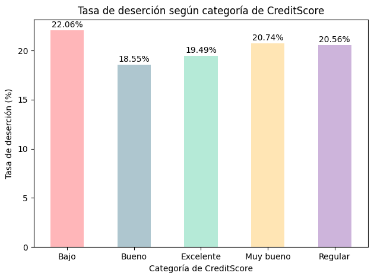

```python
import seaborn as sns
import matplotlib.pyplot as plt

grafico = tasa_desercion.copy()

colores_pastel = [
    '#FFB6B9',  # Rosa pastel
    '#AEC6CF',  # Azul pastel
    '#B5EAD7',  # Verde pastel
    '#FFE5B4',  # Amarillo pastel
    '#CDB4DB'   # Morado pastel
]

ax = grafico.plot(
    kind='bar',
    x='Categoria_CreditScore',
    y='Porcentaje',
    color=colores_pastel,
    legend=False
)

plt.title("Tasa de deserción según categoría de CreditScore")
plt.xlabel("Categoría de CreditScore")
plt.ylabel("Tasa de deserción (%)")

for i, valor in enumerate(grafico["Porcentaje"]):
    ax.text(
        i,
        valor + 0.3,
        f"{valor:.2f}%",
        ha="center"
    )

plt.xticks(rotation=0)
plt.tight_layout()
plt.show()
```

## ¿El número de productos contratados influye en la permanencia del cliente?

El análisis muestra que la deserción varía según la combinación entre el número de productos y la actividad del cliente. En los grupos con mayor cantidad de clientes, los clientes inactivos presentan una mayor tasa de abandono que los activos; por ejemplo, entre quienes tienen pocos productos, la deserción es de 36,65 % para los inactivos frente al 18,92 % para los activos. Asimismo, los clientes multiproducto activos presentan una tasa de deserción de apenas 5,56 %, frente al 9,89 % de los inactivos. Aunque los clientes con tres y cuatro productos muestran tasas de abandono muy elevadas, estos resultados deben interpretarse con cautela debido al reducido número de clientes en estas categorías. En general, los resultados sugieren que la actividad del cliente y el número de productos contratados están asociados con la deserción, destacándose especialmente el mayor abandono entre los clientes inactivos con pocos productos.

```python
NumOfProducts_df = CreditScore_df.copy()

NumOfProducts_df["Categoria_NumOfProducts"] = (NumOfProducts_df["NumOfProducts"].apply(clasificar_NumOfProducts))

NumOfProducts_df.head()
```

[output not shown]

|  | RowNumber | CustomerId | Surname | CreditScore | Geography | Gender | Age | Tenure | Balance | NumOfProducts | HasCrCard | IsActiveMember | EstimatedSalary | Exited | Rango de edades | Tipo_Clientes | Nivel_Saldo | Categoria_CreditScore | Categoria_NumOfProducts |
| --- | --- | --- | --- | --- | --- | --- | --- | --- | --- | --- | --- | --- | --- | --- | --- | --- | --- | --- | --- |
| 0 | 1 | 15634602 | Hargrave | 619 | France | Female | 42 | 2 | 0.00 | 1 | 1 | 1 | 101348.88 | 1 | Adulto Mayor | Clientes Desertores | Saldo bajo | Regular | Cliente con pocos productos |
| 1 | 2 | 15647311 | Hill | 608 | Spain | Female | 41 | 1 | 83807.86 | 1 | 0 | 1 | 112542.58 | 0 | Adulto Mayor | Clientes Retenidos | Saldo alto | Regular | Cliente con pocos productos |
| 2 | 3 | 15619304 | Onio | 502 | France | Female | 42 | 8 | 159660.80 | 3 | 1 | 0 | 113931.57 | 1 | Adulto Mayor | Clientes Desertores | Saldo alto | Bajo | Cliente multiproducto avanzado |
| 3 | 4 | 15701354 | Boni | 699 | France | Female | 39 | 1 | 0.00 | 2 | 0 | 0 | 93826.63 | 0 | Adulto Mayor | Clientes Retenidos | Saldo bajo | Bueno | Cliente multiproducto |
| 4 | 5 | 15737888 | Mitchell | 850 | Spain | Female | 43 | 2 | 125510.82 | 1 | 1 | 1 | 79084.10 | 0 | Adulto Mayor | Clientes Retenidos | Saldo alto | Excelente | Cliente con pocos productos |

```python
NumOfProducts_df["Actividad"] = NumOfProducts_df["IsActiveMember"].map({0: "Cliente Inactivo",1: "Cliente Activo"})
```

```python
resultado_productos_actividad = (NumOfProducts_df.groupby(["Categoria_NumOfProducts","Actividad","Tipo_Clientes"])["CustomerId"].count().to_frame("Clientes"))

resultado_productos_actividad["Porcentaje"] = (resultado_productos_actividad["Clientes"] /resultado_productos_actividad.groupby(level=["Categoria_NumOfProducts", "Actividad"])["Clientes"].transform("sum")* 100).round(2)

resultado_productos_actividad
```

| Categoria_NumOfProducts | Actividad | Tipo_Clientes | Clientes | Porcentaje |
| --- | --- | --- | --- | --- |
| Cliente con pocos productos | Cliente Activo | Clientes Desertores | 485 | 18.92 |
|  |  | Clientes Retenidos | 2078 | 81.08 |
|  | Cliente Inactivo | Clientes Desertores | 924 | 36.65 |
|  |  | Clientes Retenidos | 1597 | 63.35 |
| Cliente multiproducto | Cliente Activo | Clientes Desertores | 136 | 5.56 |
|  |  | Clientes Retenidos | 2310 | 94.44 |
|  | Cliente Inactivo | Clientes Desertores | 212 | 9.89 |
|  |  | Clientes Retenidos | 1932 | 90.11 |
| Cliente multiproducto avanzado | Cliente Activo | Clientes Desertores | 85 | 75.22 |
|  |  | Clientes Retenidos | 28 | 24.78 |
|  | Cliente Inactivo | Clientes Desertores | 135 | 88.24 |
|  |  | Clientes Retenidos | 18 | 11.76 |
| Cliente multiproducto intensivo | Cliente Activo | Clientes Desertores | 29 | 100.00 |
|  | Cliente Inactivo | Clientes Desertores | 31 | 100.00 |

## ¿Qué porcentaje de clientes abandona el banco según el número de productos contratados y su condición de cliente activo o inactivo?

Un cliente multiproducto avanzado y no activo tiene 88,2 % de abandono. Y esto además revela algo interesante: la actividad y la cantidad de productos están muy relacionadas con el abandono, especialmente en los grupos de multiproducto avanzado/intensivo.

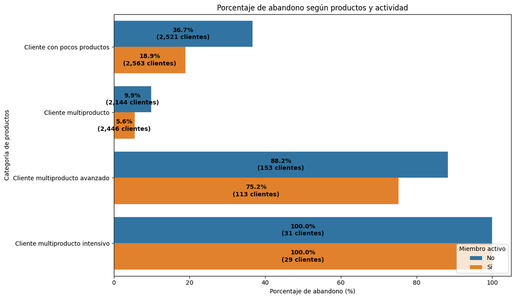

```python
import pandas as pd
import seaborn as sns
import matplotlib.pyplot as plt

tabla = NumOfProducts_df.groupby(
['Categoria_NumOfProducts', 'IsActiveMember']
).agg(
    clientes=('Exited', 'size'),
    porcentaje_abandono=('Exited', 'mean')
).reset_index()

tabla['porcentaje_abandono'] = tabla['porcentaje_abandono'] * 100

tabla['IsActiveMember'] = tabla['IsActiveMember'].map({
    0: 'No',
    1: 'Sí'
})

plt.figure(figsize=(12, 7))

ax = sns.barplot(
    data=tabla,
    x='porcentaje_abandono',
    y='Categoria_NumOfProducts',
    hue='IsActiveMember'
)

plt.title('Porcentaje de abandono según productos y actividad')
plt.xlabel('Porcentaje de abandono (%)')
plt.ylabel('Categoría de productos')

plt.legend(
    title='Miembro activo',
    loc='lower right'
)

for contenedor, (_, grupo) in zip(
    ax.containers,
    tabla.groupby('IsActiveMember')
):

    for barra, (_, fila) in zip(contenedor, grupo.iterrows()):

        porcentaje = fila['porcentaje_abandono']
        clientes = fila['clientes']

        ax.text(
            porcentaje / 2,
            barra.get_y() + barra.get_height() / 2,
            f'{porcentaje:.1f}%\n({clientes:,} clientes)',
            ha='center',
            va='center',
            color='black',
            fontweight='bold'
        )

plt.tight_layout()
plt.show()
```

## ¿Qué características tienen, en promedio, los clientes que abandonan el banco frente a los que permanecen?

encontramos algunas diferencias. Los clientes que abandonaron tienen una edad promedio de 44,84 años, mientras que los que permanecieron tienen una edad promedio de 37,41 años. También se observa que los clientes que abandonaron tenían un saldo promedio más alto, de 91.108,54, frente a 72.745,30 de los clientes que permanecieron. En cambio, variables como el CreditScore, la antigüedad, el número de productos y el salario estimado presentan diferencias pequeñas entre los dos grupos. Por lo tanto, en este análisis, la edad y el saldo son las características que muestran mayores diferencias entre los clientes que abandonaron y los que permanecieron. Sin embargo, esto no quiere decir que sean las causas directas del abandono, sino que simplemente son características que se presentan de manera diferente en ambos grupos.

```python
comparacion = df.groupby('Exited')[['CreditScore', 'Age', 'Tenure', 'Balance','NumOfProducts', 'EstimatedSalary']].mean().T
comparacion.columns = ['Permanecieron', 'Abandonaron']
comparacion['Diferencia'] = (comparacion['Abandonaron'] -comparacion['Permanecieron'])
comparacion.round(2)
```

|  | Permanecieron | Abandonaron | Diferencia |
| --- | --- | --- | --- |
| CreditScore | 651.85 | 645.35 | -6.50 |
| Age | 37.41 | 44.84 | 7.43 |
| Tenure | 5.03 | 4.93 | -0.10 |
| Balance | 72745.30 | 91108.54 | 18363.24 |
| NumOfProducts | 1.54 | 1.48 | -0.07 |
| EstimatedSalary | 99738.39 | 101465.68 | 1727.29 |

## 5. Conclusiones

En este trabajo se analizó la deserción de clientes de un banco utilizando una base de datos de 10.000 clientes. La variable principal fue Exited, que permitió identificar si un cliente abandonó o permaneció en el banco. De los 10.000 clientes analizados, 2.037 abandonaron, lo que representa el 20,37 %, mientras que el 79,63 % permaneció. Esto significa que aproximadamente 1 de cada 5 clientes abandonó el banco, lo que evidencia la importancia de implementar estrategias de retención.  
Uno de los resultados más relevantes fue la actividad de los clientes. Los clientes inactivos presentan una tasa de deserción considerablemente mayor que los clientes activos, lo que sugiere una asociación entre el nivel de actividad y la permanencia en el banco. También se encontró una diferencia importante entre los países, destacándose Alemania por presentar una mayor tasa de abandono que Francia y España.  
El número de productos también presentó resultados interesantes. Los clientes con dos productos muestran una menor tasa de deserción, mientras que los clientes con tres y cuatro productos presentan tasas considerablemente más altas. Sin embargo, estos últimos grupos cuentan con pocos clientes, por lo que sus resultados deben interpretarse con cautela. Por otra parte, el CreditScore presentó diferencias relativamente pequeñas entre las categorías analizadas, por lo que no parece ser uno de los principales factores relacionados con la deserción.  
Finalmente, al comparar las características promedio de los clientes retenidos y desertores, se encontraron diferencias principalmente en la edad y el saldo. Los clientes que abandonaron presentan una edad promedio de 44,84 años y un saldo promedio de 91.108,54, frente a 37,41 años y 72.745,30 en los clientes que permanecieron. En cambio, la antigüedad, el número promedio de productos, el CreditScore y el salario estimado presentan diferencias menores.  
**En conclusión**, el abandono de los clientes no parece estar relacionado con una única característica, sino con diferentes variables y combinaciones de características. Entre los resultados más relevantes se encuentran la actividad del cliente, el país, la combinación entre productos y actividad, así como las diferencias observadas en edad y saldo. Por esta razón, el banco debería priorizar estrategias dirigidas a los clientes inactivos, prestar especial atención al mercado alemán y analizar los segmentos con combinaciones de productos y actividad que presentan mayores tasas de abandono. Estos resultados representan asociaciones observadas en los datos y no permiten establecer que alguna de estas características sea, por sí sola, la causa directa de la deserción.

## 6. Estrategias

**1. Reactivar a los clientes inactivos**  
Una de las principales estrategias sería identificar a los clientes que actualmente presentan baja o nula actividad y desarrollar campañas de reactivación. Se podrían ofrecer promociones, beneficios especiales, ofertas personalizadas, recordatorios sobre los servicios disponibles e incentivos para volver a utilizar la aplicación y los canales digitales.

El objetivo sería recuperar la relación con estos clientes antes de que la falta de interacción se convierta en una decisión definitiva de abandonar el banco.  
2. Ofrecer productos de manera personalizada  
Los clientes que tienen pocos productos representan una oportunidad de crecimiento para el banco, pero la estrategia no debería consistir simplemente en ofrecer productos adicionales de manera generalizada. Sería más conveniente analizar las características y necesidades de cada cliente para identificar qué producto podría ser realmente útil. Por ejemplo, a un cliente que posee un solo producto se le podría ofrecer un segundo servicio que complemente el que ya utiliza.  
3. Crear un sistema de identificación temprana del riesgo de abandono  
El banco podría desarrollar un sistema de clasificación que permita identificar a los clientes con mayor probabilidad de abandonar la entidad. Variables como el nivel de actividad, número de productos, interacción con los canales digitales y comportamiento histórico podrían utilizarse para construir un indicador de riesgo. De esta manera, los clientes con mayor probabilidad de deserción podrían recibir atención antes de que se produzca el abandono.  
4. Investigar el comportamiento de los clientes con varios productos  
Los resultados muestran que tener una mayor cantidad de productos no necesariamente significa una menor probabilidad de abandono. Por esta razón, es importante analizar con mayor profundidad el comportamiento de los clientes que poseen tres o cuatro productos. El banco debería investigar si la deserción está relacionada con costos, insatisfacción, problemas con determinados productos, falta de uso, calidad del servicio u otros factores. Esto permitiría diseñar acciones específicas para este segmento.